# df

Autogenerated data summary from dataMaid

2022-03-30 18:39:25

# Data report overview

The dataset examined has the following dimensions:

| Feature | Result |
| --- | --- |
| Number of observations | 257 |
| Number of variables | 10 |

### Checks performed

The following variable checks were performed, depending on the data type of each variable:

|  | character | factor | labelled | haven labelled | numeric | integer | logical | Date |
| --- | --- | --- | --- | --- | --- | --- | --- | --- |
| Identify miscoded missing values | × | × | × | × | × | × |  | × |
| Identify prefixed and suffixed whitespace | × | × | × | × |  |  |  |  |
| Identify levels with < 6 obs. | × | × | × | × |  |  |  |  |
| Identify case issues | × | × | × | × |  |  |  |  |
| Identify misclassified numeric or integer variables | × | × | × | × |  |  |  |  |
| Identify outliers |  |  |  |  | × | × |  | × |

Please note that all numerical values in the following have been rounded to 2 decimals.

# Summary table

|  | Variable class | # unique values | Missing observations | Any problems? |
| --- | --- | --- | --- | --- |
| date | character | 257 | 0.00 % | × |
| all | numeric | 238 | 0.00 % | × |
| female | numeric | 243 | 0.00 % | × |
| male | integer | 243 | 0.00 % | × |
| young | integer | 238 | 0.00 % | × |
| adult | numeric | 242 | 0.00 % | × |
| weather | character | 2 | 0.00 % |  |
| maxtemp | integer | 23 | 0.00 % | × |
| RH | integer | 65 | 0.00 % | × |
| maxwind | integer | 26 | 0.00 % | × |

# Variable list

## date

- The variable is a key (distinct values for each observation).

## all

| Feature | Result |
| --- | --- |
| Variable type | numeric |
| Number of missing obs. | 0 (0 %) |
| Number of unique values | 238 |
| Median | 3643 |
| 1st and 3rd quartiles | 2569; 4314 |
| Min. and max. | 375; 15735 |

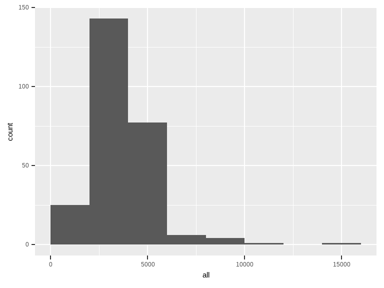

- Note that the following possible outlier values were detected: "5673", "5723", "5762", "5963", "6107", …, "8300", "9163", "9371", "11110", "15735" (6 values omitted).

## female

| Feature | Result |
| --- | --- |
| Variable type | numeric |
| Number of missing obs. | 0 (0 %) |
| Number of unique values | 243 |
| Median | 1725 |
| 1st and 3rd quartiles | 1139; 2035 |
| Min. and max. | 194; 7645 |

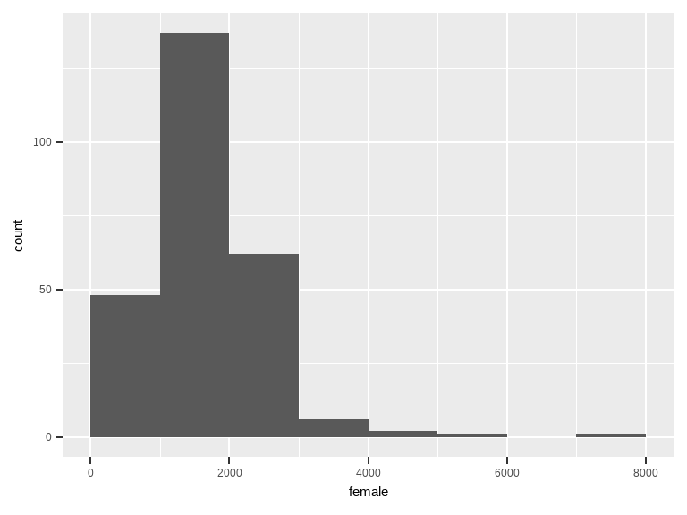

- Note that the following possible outlier values were detected: "2564", "2603", "2660", "2662", "2675", …, "3842", "4189", "4314", "5246", "7645" (12 values omitted).

## male

| Feature | Result |
| --- | --- |
| Variable type | integer |
| Number of missing obs. | 0 (0 %) |
| Number of unique values | 243 |
| Median | 1755 |
| 1st and 3rd quartiles | 1327; 2057 |
| Min. and max. | 170; 7045 |

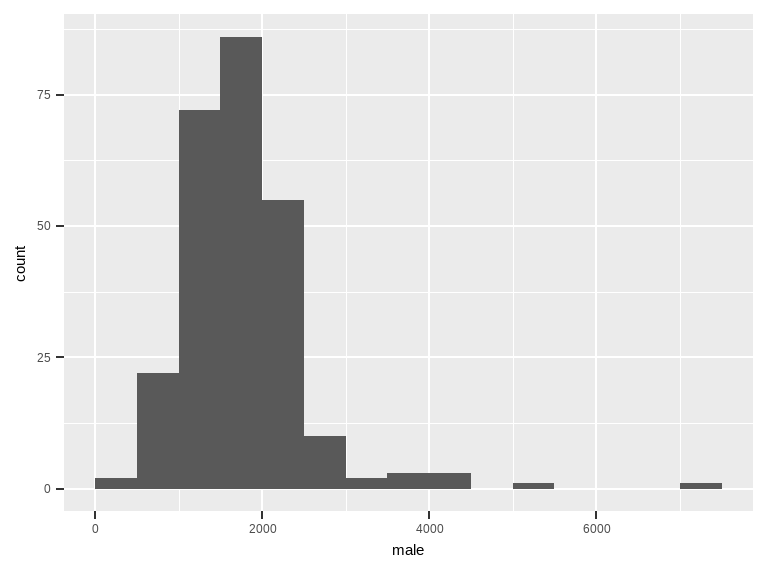

- Note that the following possible outlier values were detected: "2724", "2792", "2867", "2887", "2967", …, "4142", "4448", "4455", "5259", "7045" (5 values omitted).

## young

| Feature | Result |
| --- | --- |
| Variable type | integer |
| Number of missing obs. | 0 (0 %) |
| Number of unique values | 238 |
| Median | 1625 |
| 1st and 3rd quartiles | 1122; 1942 |
| Min. and max. | 191; 7495 |

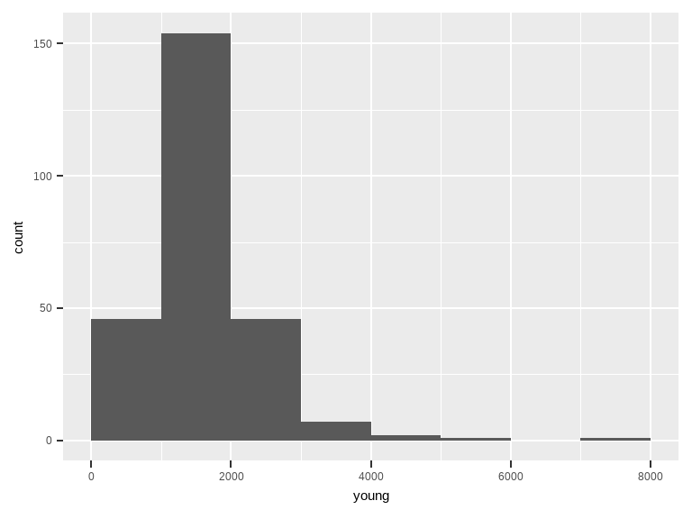

- Note that the following possible outlier values were detected: "2661", "2676", "2680", "2687", "2953", …, "3889", "4005", "4131", "5953", "7495" (7 values omitted).

## adult

| Feature | Result |
| --- | --- |
| Variable type | numeric |
| Number of missing obs. | 0 (0 %) |
| Number of unique values | 242 |
| Median | 2021 |
| 1st and 3rd quartiles | 1433; 2349 |
| Min. and max. | 184; 8240 |

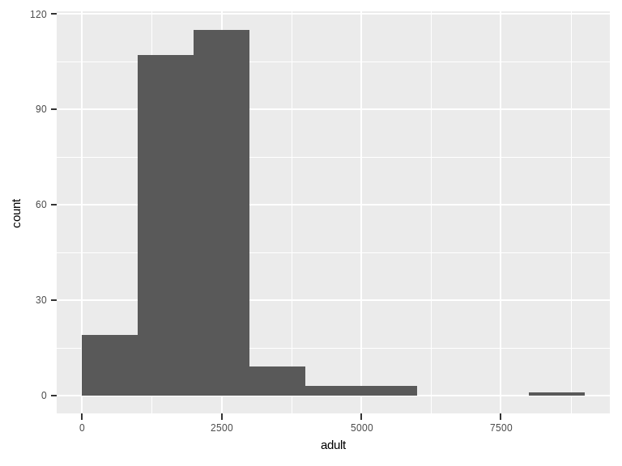

- Note that the following possible outlier values were detected: "2933", "2953", "2961", "2997", "3055", …, "4797", "5157", "5158", "5240", "8240" (10 values omitted).

## weather

| Feature | Result |
| --- | --- |
| Variable type | character |
| Number of missing obs. | 0 (0 %) |
| Number of unique values | 2 |
| Mode | “Sunny” |

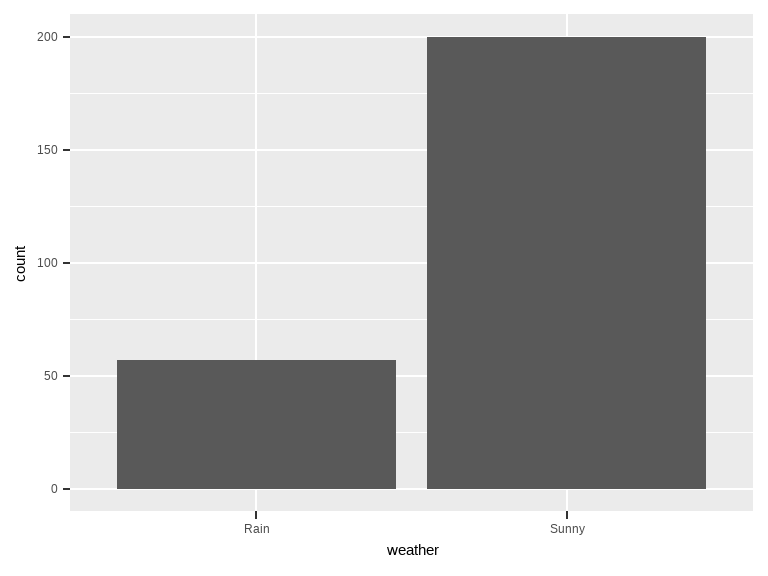

## maxtemp

| Feature | Result |
| --- | --- |
| Variable type | integer |
| Number of missing obs. | 0 (0 %) |
| Number of unique values | 23 |
| Median | 19 |
| 1st and 3rd quartiles | 16; 22 |
| Min. and max. | 7; 32 |

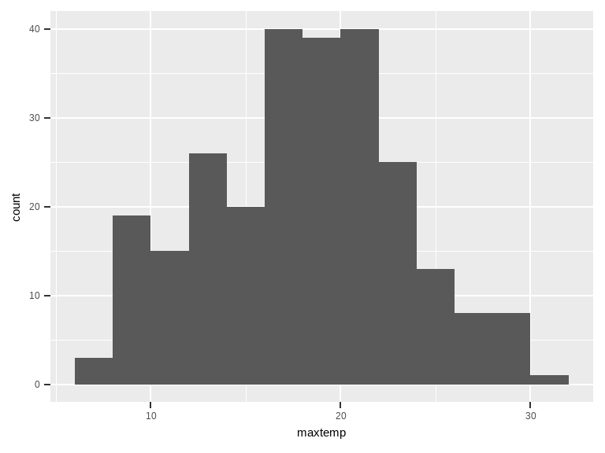

- Note that the following possible outlier values were detected: "32".

## RH

| Feature | Result |
| --- | --- |
| Variable type | integer |
| Number of missing obs. | 0 (0 %) |
| Number of unique values | 65 |
| Median | 69 |
| 1st and 3rd quartiles | 57; 78 |
| Min. and max. | 24; 99 |

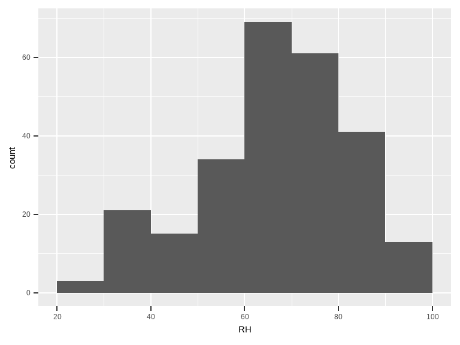

- The following suspected missing value codes enter as regular values: "99".
- Note that the following possible outlier values were detected: "99".

## maxwind

| Feature | Result |
| --- | --- |
| Variable type | integer |
| Number of missing obs. | 0 (0 %) |
| Number of unique values | 26 |
| Median | 32 |
| 1st and 3rd quartiles | 0; 42 |
| Min. and max. | 0; 74 |

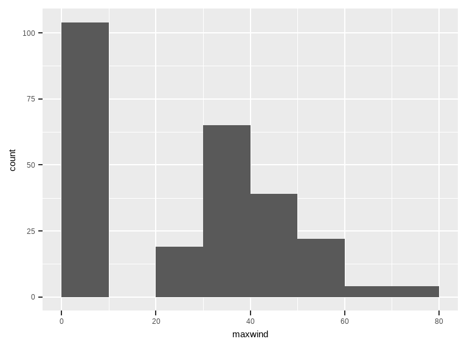

- Note that the following possible outlier values were detected: "60", "63", "64", "66", "69", "71", "74".

Report generation information:

- Created by: Carlosgoncalves00 (username: `css_l`).
- Report creation time: qua mar 30 2022 18:39:26
- Report was run from directory: `C:/Users/css_l/Desktop/TIAPOSE 2`
- dataMaid v1.4.1 [Pkg: 2021-10-08 from CRAN (R 4.1.3)]
- R version 4.1.2 (2021-11-01).
- Platform: x86_64-w64-mingw32/x64 (64-bit)(Windows 10 x64 (build 22000)).
- Function call: `makeDataReport(data = df, output = "html", file = "report/dataMaid", replace = TRUE)`